# TCGA DMAi-site usage and overall survival

07 August 2026

## Analysis overview

This manuscript analysis tests whether patient-level usage of proximal poly(A) sites responsive to dual methyltransferase inhibition (DMAi) is associated with overall survival in TCGA. The matched non-DMAi site score is included as a background APA control.

The analysis comprises:

1. a primary-tumour pan-cancer Cox model adjusted for age and sex and stratified by cancer project;
2. cancer-specific models testing the DMAi score itself;
3. parallel models testing selective DMAi usage, defined as the patient-level DMAi-minus-non-DMAi contrast while controlling for overall APA usage; and
4. adjusted survival predictions for the cancer with the strongest adverse selective-usage association.

## Methods

### Cohort and APA scores

For each RNA sample, the DMAi and non-DMAi scores were defined as the median proximal poly(A)-site usage across the corresponding experimentally defined site set. RNA samples were required to quantify at least 90% of the maximum observed number of sites in both sets. When multiple eligible RNA samples were available for one patient, their sample-level scores were collapsed using the median.

The survival analysis was restricted to patients represented by a primary solid-tumour RNA sample. Overall-survival time and status, age at diagnosis, and sex were obtained through the public cBioPortal API for the TCGA PanCancer Atlas studies and cached with the analysis inputs. Death was defined by an `OS_STATUS` value beginning with `1:`; values beginning with `0:` were censored. Patients without valid overall-survival, age, or sex data were excluded.

### Pan-cancer survival model

DMAi and non-DMAi scores were centred and scaled separately within each cancer project. A Cox proportional-hazards model included both continuous scores, age per 10-year increase, and sex. Cancer project was included as a stratum, allowing each cancer type to have its own baseline hazard. Hazard ratios therefore represent the change in mortality hazard per one within-cancer standard-deviation increase in site usage. Ties were handled using the Efron method. Proportional hazards were assessed using Schoenfeld residuals.

Selective DMAi usage was defined for each patient as DMAi median usage minus non-DMAi median usage. Overall APA usage was defined as the mean of these two scores. Both quantities were centred and scaled within cancer project. A second stratified Cox model included the selective contrast, overall APA usage, age, and sex. Adjustment for overall APA usage separates relative enrichment of DMAi-site usage from a general shift affecting both site sets.

### Cancer-specific screen

Cancer-specific Cox models were restricted to projects with at least 100 eligible patients and 30 deaths. Direct-score models included continuous within-cancer standardized DMAi usage and age per 10 years. Selective-usage models included the standardized DMAi-minus-non-DMAi contrast, standardized overall APA usage, and age. Sex was included when both sexes were represented within a cancer; it was omitted for sex-specific cancers because an invariant covariate cannot be estimated. Two-sided Wald p-values were adjusted separately across eligible cancers for the direct and selective screens using the Benjamini–Hochberg false-discovery rate (FDR). All eligible cancers are reported in the forest plots.

### Selected-cancer analysis

For visualization, adjusted survival was predicted at the within-cancer 25th and 75th percentiles of the continuous DMAi-minus-non-DMAi contrast. For each contrast value, counterfactual predictions retained every patient’s observed overall APA usage, age, and sex and were averaged across the selected-cancer cohort. This marginal standardization directly visualizes the fitted Cox model without dichotomizing patients or introducing a survival-analysis threshold. Pointwise 95% confidence intervals were estimated using 500 nonparametric patient-level bootstrap resamples. In each resample, the Cox model was refitted and survival was standardized over the resampled covariate distribution while holding the contrast at the original-cohort percentile values. Cancer selection and the adjusted survival visualization are considered exploratory. At 60 months, the adjusted survival difference between the 25th- and 75th-percentile scenarios was calculated within every paired bootstrap resample, and its 2.5th and 97.5th percentiles defined the 95% confidence interval. All tests were two-sided. Analyses were performed in R 4.5.1 using the `survival` package (version 3.8-3).

## Setup

```r
knitr::opts_chunk$set(
  echo = TRUE,
  warning = FALSE,
  message = FALSE,
  fig.width = 8,
  fig.height = 5.5,
  dpi = 120
)

required_packages <- c(
  "data.table", "ggplot2", "survival", "broom", "knitr", "scales",
  "httr2"
)
missing_packages <- required_packages[
  !vapply(required_packages, requireNamespace, logical(1), quietly = TRUE)
]
if (length(missing_packages)) {
  stop(
    "Install the missing packages before running this notebook: ",
    paste(missing_packages, collapse = ", ")
  )
}

library(data.table)
library(ggplot2)
library(survival)
library(broom)
library(knitr)
library(scales)
library(httr2)

find_repository_root <- function(start = getwd()) {
  candidate <- normalizePath(start, mustWork = TRUE)
  repeat {
    has_git_directory <- dir.exists(file.path(candidate, ".git"))
    has_repository_directories <-
      dir.exists(file.path(candidate, "Scripts")) &&
      (
        dir.exists(file.path(candidate, "Data")) ||
          dir.exists(file.path(candidate, "data"))
      )
    if (has_git_directory || has_repository_directories) {
      return(candidate)
    }
    parent <- dirname(candidate)
    if (identical(parent, candidate)) {
      stop("Could not locate the PRMT-APA repository root.")
    }
    candidate <- parent
  }
}

resolve_repository_path <- function(path, must_work = FALSE) {
  expanded_path <- path.expand(path)
  is_absolute <- grepl("^(/|[A-Za-z]:[/\\\\])", expanded_path)
  resolved_path <- if (is_absolute) {
    expanded_path
  } else {
    file.path(repository_root, expanded_path)
  }
  normalizePath(resolved_path, mustWork = must_work)
}

repository_root <- find_repository_root()

figure_output_dir <- resolve_repository_path(params$figure_output_dir)
if (!dir.exists(figure_output_dir)) {
  dir.create(figure_output_dir, recursive = TRUE)
}
figure_output_dir <- normalizePath(figure_output_dir, mustWork = TRUE)

results_output_dir <- resolve_repository_path(params$results_output_dir)
if (!dir.exists(results_output_dir)) {
  dir.create(results_output_dir, recursive = TRUE)
}
results_output_dir <- normalizePath(results_output_dir, mustWork = TRUE)

theme_set(
  theme_classic(base_size = 12) +
    theme(
      plot.title.position = "plot",
      strip.background = element_blank(),
      legend.position = "bottom"
    )
)

prediction_colours <- c(
  "Lower relative DMAi-site usage (25th percentile)" = "#1A85FF",
  "Higher relative DMAi-site usage (75th percentile)" = "#D73027"
)

standardise_score <- function(x) {
  score_sd <- sd(x, na.rm = TRUE)
  if (!is.finite(score_sd) || score_sd == 0) {
    return(rep(NA_real_, length(x)))
  }
  (x - mean(x, na.rm = TRUE)) / score_sd
}

single_value <- function(x, field, patient) {
  values <- unique(x[!is.na(x)])
  if (length(values) != 1L) {
    stop("Patient ", patient, " has multiple ", field, " values.")
  }
  values
}

tidy_score_term <- function(fit, term, model) {
  target_term <- term
  result <- as.data.table(
    tidy(fit, exponentiate = TRUE, conf.int = TRUE)
  )[term == target_term]
  data.table(
    model = model,
    hazard_ratio = result$estimate,
    conf_low = result$conf.low,
    conf_high = result$conf.high,
    p_value = result$p.value
  )
}
```

## Construct the patient cohort

```r
score_file <- resolve_repository_path(params$score_file, must_work = TRUE)
clinical_file <- resolve_repository_path(params$clinical_file)

sample_scores <- fread(score_file)
required_score_columns <- c(
  "studyId", "patientId", "project_id", "cancer_type", "sample_type",
  "dmai_median_usage", "non_dmai_median_usage",
  "n_dmai_sites_observed", "n_non_dmai_sites_observed"
)
missing_score_columns <- setdiff(
  required_score_columns,
  names(sample_scores)
)
if (length(missing_score_columns)) {
  stop(
    "The score file is missing required columns: ",
    paste(missing_score_columns, collapse = ", ")
  )
}

clinical_patient_keys <- unique(
  sample_scores[, .(studyId, patientId)]
)

sample_scores <- sample_scores[
  !is.na(studyId) &
    !is.na(patientId) &
    !is.na(project_id) &
    is.finite(dmai_median_usage) &
    is.finite(non_dmai_median_usage)
]

coverage_fraction <- as.numeric(params$minimum_site_coverage_fraction)
if (
  !is.finite(coverage_fraction) ||
    coverage_fraction <= 0 ||
    coverage_fraction > 1
) {
  stop("`minimum_site_coverage_fraction` must be in (0, 1].")
}

maximum_dmai_sites <- max(sample_scores$n_dmai_sites_observed)
maximum_non_dmai_sites <- max(sample_scores$n_non_dmai_sites_observed)
minimum_dmai_sites <- ceiling(coverage_fraction * maximum_dmai_sites)
minimum_non_dmai_sites <- ceiling(
  coverage_fraction * maximum_non_dmai_sites
)

n_samples_before_coverage <- nrow(sample_scores)
sample_scores <- sample_scores[
  n_dmai_sites_observed >= minimum_dmai_sites &
    n_non_dmai_sites_observed >= minimum_non_dmai_sites
]

coverage_qc <- data.table(
  site_group = c("DMAi", "non-DMAi"),
  maximum_observed_sites = c(
    maximum_dmai_sites,
    maximum_non_dmai_sites
  ),
  minimum_required_sites = c(
    minimum_dmai_sites,
    minimum_non_dmai_sites
  ),
  samples_before_filter = n_samples_before_coverage,
  samples_after_filter = nrow(sample_scores),
  samples_excluded = n_samples_before_coverage - nrow(sample_scores)
)
kable(
  coverage_qc,
  caption = "APA site-coverage filter"
)
```

APA site-coverage filter

| site_group | maximum_observed_sites | minimum_required_sites | samples_before_filter | samples_after_filter | samples_excluded |
| --- | --- | --- | --- | --- | --- |
| DMAi | 205 | 185 | 10085 | 10074 | 11 |
| non-DMAi | 221 | 199 | 10085 | 10074 | 11 |

```r
required_clinical_attributes <- c(
  "OS_MONTHS", "OS_STATUS", "AGE", "SEX"
)

fetch_cbioportal_patient_clinical <- function(
  study_ids,
  api_base_url
) {
  api_base_url <- sub("/+$", "", api_base_url)
  clinical_by_study <- lapply(sort(unique(study_ids)), function(study_id) {
    endpoint <- paste0(
      api_base_url,
      "/studies/",
      utils::URLencode(study_id, reserved = TRUE),
      "/clinical-data"
    )
    response <- request(endpoint) |>
      req_url_query(
        clinicalDataType = "PATIENT",
        projection = "SUMMARY",
        pageSize = 100000,
        pageNumber = 0
      ) |>
      req_user_agent("PRMT-APA survival analysis") |>
      req_timeout(seconds = 60) |>
      req_retry(max_tries = 5) |>
      req_perform()

    study_clinical <- as.data.table(
      resp_body_json(response, simplifyVector = TRUE)
    )
    required_api_columns <- c(
      "studyId", "patientId", "clinicalAttributeId", "value"
    )
    missing_api_columns <- setdiff(
      required_api_columns,
      names(study_clinical)
    )
    if (length(missing_api_columns)) {
      stop(
        "cBioPortal returned an unexpected clinical-data response for ",
        study_id,
        "."
      )
    }
    study_clinical[
      clinicalAttributeId %chin% required_clinical_attributes,
      ..required_api_columns
    ]
  })

  clinical_long <- rbindlist(clinical_by_study, use.names = TRUE)
  duplicated_attributes <- clinical_long[
    , .N,
    by = .(studyId, patientId, clinicalAttributeId)
  ][N > 1L]
  if (nrow(duplicated_attributes)) {
    stop("cBioPortal returned duplicate patient clinical attributes.")
  }

  clinical_wide <- dcast(
    clinical_long,
    studyId + patientId ~ clinicalAttributeId,
    value.var = "value"
  )
  missing_attributes <- setdiff(
    required_clinical_attributes,
    names(clinical_wide)
  )
  if (length(missing_attributes)) {
    stop(
      "The downloaded clinical data lack required attributes: ",
      paste(missing_attributes, collapse = ", ")
    )
  }
  setcolorder(
    clinical_wide,
    c("studyId", "patientId", required_clinical_attributes)
  )
  setorder(clinical_wide, studyId, patientId)
  clinical_wide[, retrieved_utc := format(
    Sys.time(),
    tz = "UTC",
    usetz = TRUE
  )]
  clinical_wide
}

refresh_clinical <- isTRUE(params$refresh_clinical)
clinical_was_downloaded <- refresh_clinical || !file.exists(clinical_file)
if (clinical_was_downloaded) {
  dir.create(
    dirname(clinical_file),
    recursive = TRUE,
    showWarnings = FALSE
  )
  downloaded_clinical <- fetch_cbioportal_patient_clinical(
    clinical_patient_keys$studyId,
    params$cbioportal_api_url
  )
  downloaded_clinical <- merge(
    clinical_patient_keys,
    downloaded_clinical,
    by = c("studyId", "patientId"),
    all.x = TRUE
  )
  downloaded_clinical[, retrieved_utc := format(
    Sys.time(),
    tz = "UTC",
    usetz = TRUE
  )]
  setorder(downloaded_clinical, studyId, patientId)
  fwrite(downloaded_clinical, clinical_file, sep = "\t")
}
clinical_file <- normalizePath(clinical_file, mustWork = TRUE)

clinical_cache_qc <- data.table(
  source = if (
    clinical_was_downloaded
  ) "Downloaded from cBioPortal API" else "Existing committed cache",
  clinical_file = clinical_file,
  studies_requested = uniqueN(clinical_patient_keys$studyId),
  retrieved_utc = paste(
    unique(fread(
      clinical_file,
      select = "retrieved_utc",
      colClasses = "character"
    )$retrieved_utc),
    collapse = "; "
  )
)
kable(clinical_cache_qc, caption = "Clinical-data provenance")
```

Clinical-data provenance

| source | clinical_file | studies_requested | retrieved_utc |
| --- | --- | --- | --- |
| Existing committed cache | /Users/capitac/repos/PRMT-APA/data/Figure_5_6_S8_S9/tcga_pancan_patient_clinical.tsv | 32 | 2026-08-07 12:12:01 UTC |

```r
patient_usage <- sample_scores[, {
  current_patient <- patientId[1L]
  list(
    project_id = single_value(
      project_id,
      "project_id",
      current_patient
    ),
    cancer_type = single_value(
      cancer_type,
      "cancer_type",
      current_patient
    ),
    n_apa_samples = .N,
    sample_types = paste(
      sort(unique(sample_type[!is.na(sample_type)])),
      collapse = "; "
    ),
    minimum_dmai_sites_observed = min(n_dmai_sites_observed),
    minimum_non_dmai_sites_observed = min(
      n_non_dmai_sites_observed
    ),
    dmai_median_usage = median(dmai_median_usage),
    non_dmai_median_usage = median(non_dmai_median_usage)
  )
}, by = .(studyId, patientId)]

if (anyDuplicated(patient_usage[, .(studyId, patientId)])) {
  stop("Patient-level APA data contain duplicate study/patient keys.")
}
```

```r
clinical_data <- fread(
  clinical_file,
  colClasses = "character"
)
required_clinical_columns <- c(
  "studyId", "patientId", "OS_MONTHS", "OS_STATUS", "AGE", "SEX"
)
missing_clinical_columns <- setdiff(
  required_clinical_columns,
  names(clinical_data)
)
if (length(missing_clinical_columns)) {
  stop(
    "The clinical file is missing required columns: ",
    paste(missing_clinical_columns, collapse = ", ")
  )
}

analysis_data <- merge(
  patient_usage,
  clinical_data[, ..required_clinical_columns],
  by = c("studyId", "patientId"),
  all = FALSE
)
analysis_data[, os_months := suppressWarnings(as.numeric(OS_MONTHS))]
analysis_data[
  !is.na(OS_STATUS) & !nzchar(trimws(OS_STATUS)),
  OS_STATUS := NA_character_
]
analysis_data[, os_event := fcase(
  grepl("^1:", OS_STATUS), 1L,
  grepl("^0:", OS_STATUS), 0L,
  default = NA_integer_
)]
analysis_data[, age_years := suppressWarnings(as.numeric(AGE))]
analysis_data[
  !is.finite(age_years) | age_years <= 0 | age_years >= 120,
  age_years := NA_real_
]
analysis_data[, sex := factor(
  fcase(
    toupper(trimws(SEX)) == "FEMALE", "Female",
    toupper(trimws(SEX)) == "MALE", "Male",
    default = NA_character_
  ),
  levels = c("Female", "Male")
)]

primary_sample_types <- c("Primary Tumor", "Primary solid Tumor")
is_valid_survival <- is.finite(analysis_data$os_months) &
  analysis_data$os_months >= 0 &
  !is.na(analysis_data$os_event)
is_primary <- analysis_data$sample_types %chin% primary_sample_types
is_clinically_complete <- !is.na(analysis_data$age_years) &
  !is.na(analysis_data$sex)

cohort_flow <- data.table(
  analysis_step = c(
    "Patients with APA and clinical mapping",
    "Valid overall-survival endpoint",
    "Primary solid-tumour RNA sample",
    "Complete age and sex"
  ),
  patients = c(
    nrow(analysis_data),
    sum(is_valid_survival),
    sum(is_valid_survival & is_primary),
    sum(is_valid_survival & is_primary & is_clinically_complete)
  )
)
kable(cohort_flow, caption = "Survival cohort construction")
```

Survival cohort construction

| analysis_step | patients |
| --- | --- |
| Patients with APA and clinical mapping | 10066 |
| Valid overall-survival endpoint | 9988 |
| Primary solid-tumour RNA sample | 9463 |
| Complete age and sex | 9227 |

```r
analysis_data <- analysis_data[
  is_valid_survival &
    is_primary &
    is_clinically_complete
]
analysis_data[, age_per_10_years := age_years / 10]
analysis_data[, dmai_usage_z := standardise_score(
  dmai_median_usage
), by = project_id]
analysis_data[, non_dmai_usage_z := standardise_score(
  non_dmai_median_usage
), by = project_id]
analysis_data[, selective_dmai_usage :=
  dmai_median_usage - non_dmai_median_usage]
analysis_data[, overall_apa_usage :=
  (dmai_median_usage + non_dmai_median_usage) / 2]
analysis_data[, selective_dmai_usage_z := standardise_score(
  selective_dmai_usage
), by = project_id]
analysis_data[, overall_apa_usage_z := standardise_score(
  overall_apa_usage
), by = project_id]
analysis_data <- analysis_data[
  is.finite(dmai_usage_z) &
    is.finite(non_dmai_usage_z) &
    is.finite(selective_dmai_usage_z) &
    is.finite(overall_apa_usage_z)
]

cohort_summary <- analysis_data[, .(
  patients = .N,
  deaths = sum(os_event),
  cancer_projects = uniqueN(project_id),
  patients_with_multiple_apa_samples = sum(n_apa_samples > 1L)
)]
kable(
  cohort_summary,
  caption = "Final primary-tumour age/sex analysis cohort"
)
```

Final primary-tumour age/sex analysis cohort

| patients | deaths | cancer_projects | patients_with_multiple_apa_samples |
| --- | --- | --- | --- |
| 9227 | 2555 | 31 | 0 |

## Primary pan-cancer Cox model

```r
pan_cancer_fit <- coxph(
  Surv(os_months, os_event) ~
    dmai_usage_z +
    non_dmai_usage_z +
    age_per_10_years +
    sex +
    strata(project_id),
  data = analysis_data,
  ties = "efron",
  x = TRUE
)

pan_cancer_results <- rbindlist(list(
  tidy_score_term(
    pan_cancer_fit,
    "dmai_usage_z",
    "DMAi"
  ),
  tidy_score_term(
    pan_cancer_fit,
    "non_dmai_usage_z",
    "non-DMAi"
  )
))
kable(
  pan_cancer_results,
  digits = 4,
  caption = paste(
    "Age- and sex-adjusted pan-cancer overall-survival Cox model"
  )
)
```

Age- and sex-adjusted pan-cancer overall-survival Cox model

| model | hazard_ratio | conf_low | conf_high | p_value |
| --- | --- | --- | --- | --- |
| DMAi | 1.1070 | 1.0109 | 1.2122 | 0.0282 |
| non-DMAi | 0.9826 | 0.8969 | 1.0763 | 0.7051 |

```r
pan_cancer_ph <- cox.zph(pan_cancer_fit, transform = "km")
pan_cancer_ph_results <- as.data.table(
  as.data.frame(pan_cancer_ph$table),
  keep.rownames = "term"
)
setnames(pan_cancer_ph_results, old = "p", new = "p_value")
kable(
  pan_cancer_ph_results,
  digits = 4,
  caption = "Schoenfeld residual tests"
)
```

Schoenfeld residual tests

| term | chisq | df | p_value |
| --- | --- | --- | --- |
| dmai_usage_z | 0.7528 | 1 | 0.3856 |
| non_dmai_usage_z | 0.1890 | 1 | 0.6637 |
| age_per_10_years | 0.0022 | 1 | 0.9625 |
| sex | 0.4653 | 1 | 0.4952 |
| GLOBAL | 1.8778 | 4 | 0.7582 |

```r
selective_pan_cancer_fit <- coxph(
  Surv(os_months, os_event) ~
    selective_dmai_usage_z +
    overall_apa_usage_z +
    age_per_10_years +
    sex +
    strata(project_id),
  data = analysis_data,
  ties = "efron",
  x = TRUE
)

selective_pan_cancer_results <- rbindlist(list(
  tidy_score_term(
    selective_pan_cancer_fit,
    "selective_dmai_usage_z",
    "Selective DMAi usage"
  ),
  tidy_score_term(
    selective_pan_cancer_fit,
    "overall_apa_usage_z",
    "Overall APA usage"
  )
))
kable(
  selective_pan_cancer_results,
  digits = 4,
  caption = paste(
    "Pan-cancer selective DMAi model adjusted for overall APA usage,",
    "age, and sex"
  )
)
```

Pan-cancer selective DMAi model adjusted for overall APA usage, age, and sex

| model | hazard_ratio | conf_low | conf_high | p_value |
| --- | --- | --- | --- | --- |
| Selective DMAi usage | 1.0335 | 0.9933 | 1.0754 | 0.1033 |
| Overall APA usage | 1.0775 | 1.0342 | 1.1226 | 0.0004 |

```r
selective_pan_cancer_ph <- cox.zph(
  selective_pan_cancer_fit,
  transform = "km"
)
selective_pan_cancer_ph_results <- as.data.table(
  as.data.frame(selective_pan_cancer_ph$table),
  keep.rownames = "term"
)
setnames(
  selective_pan_cancer_ph_results,
  old = "p",
  new = "p_value"
)
kable(
  selective_pan_cancer_ph_results,
  digits = 4,
  caption = "Selective-model Schoenfeld residual tests"
)
```

Selective-model Schoenfeld residual tests

| term | chisq | df | p_value |
| --- | --- | --- | --- |
| selective_dmai_usage_z | 1.6226 | 1 | 0.2027 |
| overall_apa_usage_z | 0.5012 | 1 | 0.4790 |
| age_per_10_years | 0.0023 | 1 | 0.9615 |
| sex | 0.4378 | 1 | 0.5082 |
| GLOBAL | 2.3266 | 4 | 0.6759 |

## Cancer-specific direct and selective DMAi screens

```r
cancer_variability <- analysis_data[, .(
  cancer_type = cancer_type[1L],
  patients = .N,
  deaths = sum(os_event),
  mean_dmai_usage = mean(dmai_median_usage),
  sd_dmai_usage = sd(dmai_median_usage),
  iqr_dmai_usage = IQR(dmai_median_usage),
  dmai_non_dmai_spearman = cor(
    dmai_median_usage,
    non_dmai_median_usage,
    method = "spearman"
  )
), by = project_id]
cancer_variability[
  ,
  dmai_sd_rank := frank(-sd_dmai_usage, ties.method = "min")
]
cancer_variability[
  ,
  dmai_iqr_rank := frank(-iqr_dmai_usage, ties.method = "min")
]
```

```r
fit_cancer_score <- function(
  cancer_data,
  score_term,
  analysis_name,
  additional_terms = character()
) {
  n_patients <- nrow(cancer_data)
  n_events <- sum(cancer_data$os_event)
  if (
    n_patients < params$minimum_project_patients ||
      n_events < params$minimum_project_events
  ) {
    return(NULL)
  }

  cancer_data <- droplevels(as.data.frame(copy(cancer_data)))
  adjust_for_sex <- nlevels(cancer_data$sex) > 1L
  model_terms <- c(
    score_term,
    additional_terms,
    "age_per_10_years"
  )
  if (adjust_for_sex) {
    model_terms <- c(model_terms, "sex")
  }
  model_formula <- as.formula(paste(
    "Surv(os_months, os_event) ~",
    paste(model_terms, collapse = " + ")
  ))

  fit <- tryCatch(
    coxph(
      model_formula,
      data = cancer_data,
      ties = "efron",
      x = TRUE
    ),
    error = function(e) {
      stop(
        "Cancer-specific model failed for ",
        cancer_data$project_id[1L],
        " (", analysis_name, "): ",
        conditionMessage(e)
      )
    }
  )

  target_term <- score_term
  score_result <- as.data.table(
    tidy(fit, exponentiate = TRUE, conf.int = TRUE)
  )[term == target_term]
  if (!nrow(score_result)) {
    stop(
      "Score term was not estimated for ",
      cancer_data$project_id[1L],
      " (", analysis_name, ")."
    )
  }

  ph_global_p <- tryCatch(
    cox.zph(fit, transform = "km")$table["GLOBAL", "p"],
    error = function(e) NA_real_
  )

  data.table(
    analysis = analysis_name,
    project_id = cancer_data$project_id[1L],
    cancer_type = cancer_data$cancer_type[1L],
    patients = n_patients,
    deaths = n_events,
    clinical_adjustment = if (
      adjust_for_sex
    ) "Age and sex" else "Age; sex invariant",
    hazard_ratio = score_result$estimate,
    conf_low = score_result$conf.low,
    conf_high = score_result$conf.high,
    p_value = score_result$p.value,
    ph_global_p = ph_global_p
  )
}

direct_cancer_results <- rbindlist(
  lapply(
    split(analysis_data, analysis_data$project_id),
    fit_cancer_score,
    score_term = "dmai_usage_z",
    analysis_name = "DMAi score"
  ),
  use.names = TRUE,
  fill = TRUE
)

selective_cancer_results <- rbindlist(
  lapply(
    split(analysis_data, analysis_data$project_id),
    fit_cancer_score,
    score_term = "selective_dmai_usage_z",
    analysis_name = "Selective DMAi contrast",
    additional_terms = "overall_apa_usage_z"
  ),
  use.names = TRUE,
  fill = TRUE
)

if (!nrow(direct_cancer_results) || !nrow(selective_cancer_results)) {
  stop("No cancer project met the patient and event thresholds.")
}
if (!identical(
  sort(direct_cancer_results$project_id),
  sort(selective_cancer_results$project_id)
)) {
  stop("The direct and selective screens contain different cancer projects.")
}

cancer_screen_results <- rbindlist(list(
  direct_cancer_results,
  selective_cancer_results
))
cancer_screen_results[, p_adjusted := p.adjust(
  p_value,
  method = "BH"
), by = analysis]
cancer_screen_results[
  ,
  impact_rank := frank(-hazard_ratio, ties.method = "first")
  ,
  by = analysis
]
cancer_screen_results[
  ,
  evidence_rank := frank(p_value, ties.method = "first")
  ,
  by = analysis
]
setorder(cancer_screen_results, analysis, evidence_rank)

direct_cancer_results <- cancer_screen_results[
  analysis == "DMAi score"
]
selective_cancer_results <- cancer_screen_results[
  analysis == "Selective DMAi contrast"
]

kable(
  direct_cancer_results,
  digits = 4,
  caption = paste0(
    "Cancer-specific direct DMAi-score models; ",
    "eligibility: n >= ",
    params$minimum_project_patients,
    " and deaths >= ",
    params$minimum_project_events
  )
)
```

Cancer-specific direct DMAi-score models; eligibility: n >= 100 and deaths >= 30

| analysis | project_id | cancer_type | patients | deaths | clinical_adjustment | hazard_ratio | conf_low | conf_high | p_value | ph_global_p | p_adjusted | impact_rank | evidence_rank |
| --- | --- | --- | --- | --- | --- | --- | --- | --- | --- | --- | --- | --- | --- |
| DMAi score | TCGA-PAAD | Pancreatic Adenocarcinoma | 176 | 92 | Age and sex | 1.5723 | 1.2341 | 2.0032 | 0.0002 | 0.1856 | 0.0045 | 1 | 1 |
| DMAi score | TCGA-CESC | Cervical Squamous Cell Carcinoma and Endocervical Adenocarcinoma | 293 | 67 | Age; sex invariant | 1.5017 | 1.1265 | 2.0019 | 0.0056 | 0.3647 | 0.0502 | 2 | 2 |
| DMAi score | TCGA-LGG | Brain Lower Grade Glioma | 509 | 125 | Age and sex | 1.3028 | 1.0644 | 1.5948 | 0.0103 | 0.0041 | 0.0589 | 4 | 3 |
| DMAi score | TCGA-BLCA | Bladder Urothelial Carcinoma | 404 | 177 | Age and sex | 1.2193 | 1.0425 | 1.4260 | 0.0131 | 0.0849 | 0.0589 | 6 | 4 |
| DMAi score | TCGA-KIRC | Kidney Renal Clear Cell Carcinoma | 445 | 143 | Age and sex | 0.8425 | 0.7265 | 0.9769 | 0.0233 | 0.2555 | 0.0838 | 18 | 5 |
| DMAi score | TCGA-UCEC | Uterine Corpus Endometrial Carcinoma | 519 | 86 | Age; sex invariant | 1.2260 | 0.9856 | 1.5252 | 0.0673 | 0.5774 | 0.2019 | 5 | 6 |
| DMAi score | TCGA-KIRP | Kidney Renal Papillary Cell Carcinoma | 280 | 41 | Age and sex | 1.3396 | 0.9454 | 1.8983 | 0.1001 | 0.0769 | 0.2575 | 3 | 7 |
| DMAi score | TCGA-BRCA | Breast Invasive Carcinoma | 1081 | 151 | Age and sex | 1.1308 | 0.9595 | 1.3326 | 0.1425 | 0.5890 | 0.2914 | 7 | 8 |
| DMAi score | TCGA-HNSC | Head and Neck Squamous Cell Carcinoma | 490 | 209 | Age and sex | 1.1189 | 0.9617 | 1.3017 | 0.1457 | 0.8607 | 0.2914 | 8 | 9 |
| DMAi score | TCGA-LUAD | Lung Adenocarcinoma | 492 | 178 | Age and sex | 1.0972 | 0.9477 | 1.2702 | 0.2146 | 0.0636 | 0.3863 | 9 | 10 |
| DMAi score | TCGA-OV | Ovarian Serous Cystadenocarcinoma | 353 | 215 | Age; sex invariant | 1.0741 | 0.9355 | 1.2331 | 0.3107 | 0.0061 | 0.5084 | 10 | 11 |
| DMAi score | TCGA-LUSC | Lung Squamous Cell Carcinoma | 470 | 201 | Age and sex | 1.0679 | 0.9311 | 1.2248 | 0.3478 | 0.7206 | 0.5211 | 11 | 12 |
| DMAi score | TCGA-COAD | Colon Adenocarcinoma | 426 | 96 | Age and sex | 0.9117 | 0.7429 | 1.1189 | 0.3764 | 0.4946 | 0.5211 | 17 | 13 |
| DMAi score | TCGA-LIHC | Liver Hepatocellular Carcinoma | 365 | 129 | Age and sex | 1.0664 | 0.9015 | 1.2614 | 0.4535 | 0.3390 | 0.5831 | 12 | 14 |
| DMAi score | TCGA-STAD | Stomach Adenocarcinoma | 405 | 156 | Age and sex | 0.9617 | 0.8175 | 1.1314 | 0.6377 | 0.2503 | 0.7653 | 16 | 15 |
| DMAi score | TCGA-SARC | Sarcoma | 252 | 95 | Age and sex | 1.0341 | 0.8512 | 1.2563 | 0.7356 | 0.8019 | 0.8276 | 13 | 16 |
| DMAi score | TCGA-GBM | Glioblastoma Multiforme | 105 | 74 | Age and sex | 0.9819 | 0.7741 | 1.2456 | 0.8806 | 0.4626 | 0.9169 | 15 | 17 |
| DMAi score | TCGA-ESCA | Esophageal Carcinoma | 181 | 76 | Age and sex | 0.9884 | 0.7931 | 1.2317 | 0.9169 | 0.1307 | 0.9169 | 14 | 18 |

```r
kable(
  selective_cancer_results,
  digits = 4,
  caption = paste0(
    "Cancer-specific selective DMAi models adjusted for overall APA; ",
    "eligibility: n >= ",
    params$minimum_project_patients,
    " and deaths >= ",
    params$minimum_project_events
  )
)
```

Cancer-specific selective DMAi models adjusted for overall APA; eligibility: n >= 100 and deaths >= 30

| analysis | project_id | cancer_type | patients | deaths | clinical_adjustment | hazard_ratio | conf_low | conf_high | p_value | ph_global_p | p_adjusted | impact_rank | evidence_rank |
| --- | --- | --- | --- | --- | --- | --- | --- | --- | --- | --- | --- | --- | --- |
| Selective DMAi contrast | TCGA-KIRC | Kidney Renal Clear Cell Carcinoma | 445 | 143 | Age and sex | 1.3466 | 1.1658 | 1.5555 | 0.0001 | 0.3733 | 0.0009 | 1 | 1 |
| Selective DMAi contrast | TCGA-BLCA | Bladder Urothelial Carcinoma | 404 | 177 | Age and sex | 0.7795 | 0.6598 | 0.9210 | 0.0034 | 0.0993 | 0.0307 | 18 | 2 |
| Selective DMAi contrast | TCGA-STAD | Stomach Adenocarcinoma | 405 | 156 | Age and sex | 0.8379 | 0.7072 | 0.9927 | 0.0409 | 0.2039 | 0.2456 | 17 | 3 |
| Selective DMAi contrast | TCGA-PAAD | Pancreatic Adenocarcinoma | 176 | 92 | Age and sex | 1.2290 | 0.9640 | 1.5669 | 0.0962 | 0.2714 | 0.3347 | 5 | 4 |
| Selective DMAi contrast | TCGA-GBM | Glioblastoma Multiforme | 105 | 74 | Age and sex | 1.2418 | 0.9531 | 1.6180 | 0.1086 | 0.4244 | 0.3347 | 4 | 5 |
| Selective DMAi contrast | TCGA-LGG | Brain Lower Grade Glioma | 509 | 125 | Age and sex | 1.2530 | 0.9468 | 1.6583 | 0.1147 | 0.0098 | 0.3347 | 3 | 6 |
| Selective DMAi contrast | TCGA-UCEC | Uterine Corpus Endometrial Carcinoma | 519 | 86 | Age; sex invariant | 1.1668 | 0.9555 | 1.4247 | 0.1302 | 0.5085 | 0.3347 | 6 | 7 |
| Selective DMAi contrast | TCGA-KIRP | Kidney Renal Papillary Cell Carcinoma | 280 | 41 | Age and sex | 1.2835 | 0.8419 | 1.9567 | 0.2460 | 0.1569 | 0.5109 | 2 | 8 |
| Selective DMAi contrast | TCGA-ESCA | Esophageal Carcinoma | 181 | 76 | Age and sex | 1.1429 | 0.9079 | 1.4389 | 0.2555 | 0.1808 | 0.5109 | 7 | 9 |
| Selective DMAi contrast | TCGA-SARC | Sarcoma | 252 | 95 | Age and sex | 0.8950 | 0.7151 | 1.1203 | 0.3329 | 0.9019 | 0.5993 | 16 | 10 |
| Selective DMAi contrast | TCGA-CESC | Cervical Squamous Cell Carcinoma and Endocervical Adenocarcinoma | 293 | 67 | Age; sex invariant | 1.1065 | 0.8475 | 1.4447 | 0.4568 | 0.4704 | 0.7475 | 8 | 11 |
| Selective DMAi contrast | TCGA-OV | Ovarian Serous Cystadenocarcinoma | 353 | 215 | Age; sex invariant | 1.0465 | 0.9065 | 1.2081 | 0.5354 | 0.0121 | 0.8031 | 9 | 12 |
| Selective DMAi contrast | TCGA-LIHC | Liver Hepatocellular Carcinoma | 365 | 129 | Age and sex | 0.9535 | 0.8034 | 1.1317 | 0.5860 | 0.2337 | 0.8078 | 15 | 13 |
| Selective DMAi contrast | TCGA-LUSC | Lung Squamous Cell Carcinoma | 470 | 201 | Age and sex | 1.0360 | 0.8977 | 1.1957 | 0.6283 | 0.8354 | 0.8078 | 10 | 14 |
| Selective DMAi contrast | TCGA-BRCA | Breast Invasive Carcinoma | 1081 | 151 | Age and sex | 1.0288 | 0.8625 | 1.2272 | 0.7522 | 0.1273 | 0.9026 | 11 | 15 |
| Selective DMAi contrast | TCGA-COAD | Colon Adenocarcinoma | 426 | 96 | Age and sex | 0.9744 | 0.7954 | 1.1938 | 0.8024 | 0.6330 | 0.9027 | 14 | 16 |
| Selective DMAi contrast | TCGA-LUAD | Lung Adenocarcinoma | 492 | 178 | Age and sex | 1.0129 | 0.8739 | 1.1741 | 0.8644 | 0.0776 | 0.9106 | 12 | 17 |
| Selective DMAi contrast | TCGA-HNSC | Head and Neck Squamous Cell Carcinoma | 490 | 209 | Age and sex | 0.9926 | 0.8712 | 1.1308 | 0.9106 | 0.9293 | 0.9106 | 13 | 18 |

```r
make_cancer_forest <- function(
  results,
  selected_project,
  x_label
) {
  plot_data <- copy(results)
  forest_order <- plot_data[order(hazard_ratio), project_id]
  ordered_data <- plot_data[match(forest_order, project_id)]
  ordered_labels <- paste0(
    ordered_data$project_id,
    " (n=", ordered_data$patients,
    ", deaths=", ordered_data$deaths, ")"
  )
  plot_data[, project_label := factor(
    paste0(project_id, " (n=", patients, ", deaths=", deaths, ")"),
    levels = ordered_labels
  )]
  plot_data[, selected := factor(
    fifelse(
      project_id == selected_project,
      selected_project,
      "Other eligible cancers"
    ),
    levels = c("Other eligible cancers", selected_project)
  )]

  ggplot(
    plot_data,
    aes(
      hazard_ratio,
      project_label,
      xmin = conf_low,
      xmax = conf_high,
      colour = selected
    )
  ) +
    geom_vline(xintercept = 1, linetype = 2, colour = "#777777") +
    geom_errorbar(orientation = "y", width = 0.15) +
    geom_point(size = 2.2) +
    scale_x_log10() +
    scale_colour_manual(values = setNames(
      c("#555555", "#D73027"),
      c("Other eligible cancers", selected_project)
    )) +
    labs(x = x_label, y = NULL, colour = NULL) +
    theme_classic(base_size = 16) +
    theme(
      aspect.ratio = 1,
      axis.text.x = element_text(size = 13),
      axis.text.y = element_text(size = 10),
      axis.title.x = element_text(size = 15),
      legend.position = "bottom",
      legend.text = element_text(size = 11.5)
    )
}
```

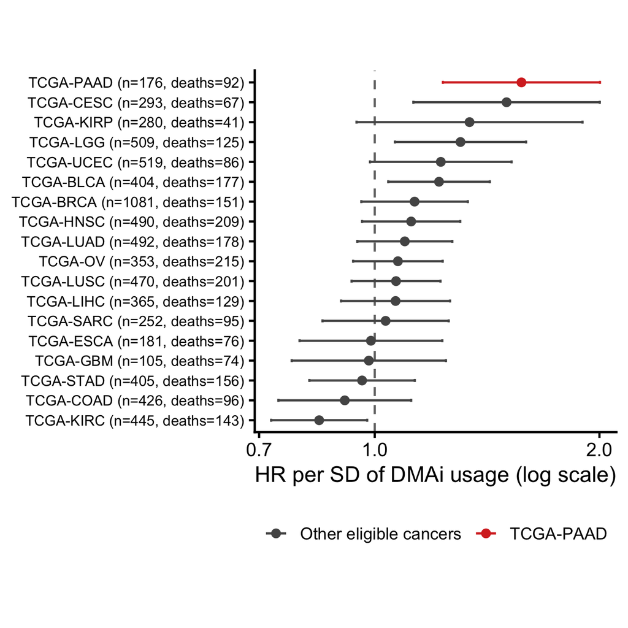

```r
direct_cancer_forest_plot <- make_cancer_forest(
  direct_cancer_results,
  params$selected_direct_project,
  "HR per SD of DMAi usage (log scale)"
)

direct_cancer_forest_plot
```

```r
ggsave(
  file.path(
    figure_output_dir,
    "tcga_dmai_survival_forest_panel.pdf"
  ),
  plot = direct_cancer_forest_plot,
  device = pdf,
  width = 6,
  height = 6,
  units = "in"
)
```

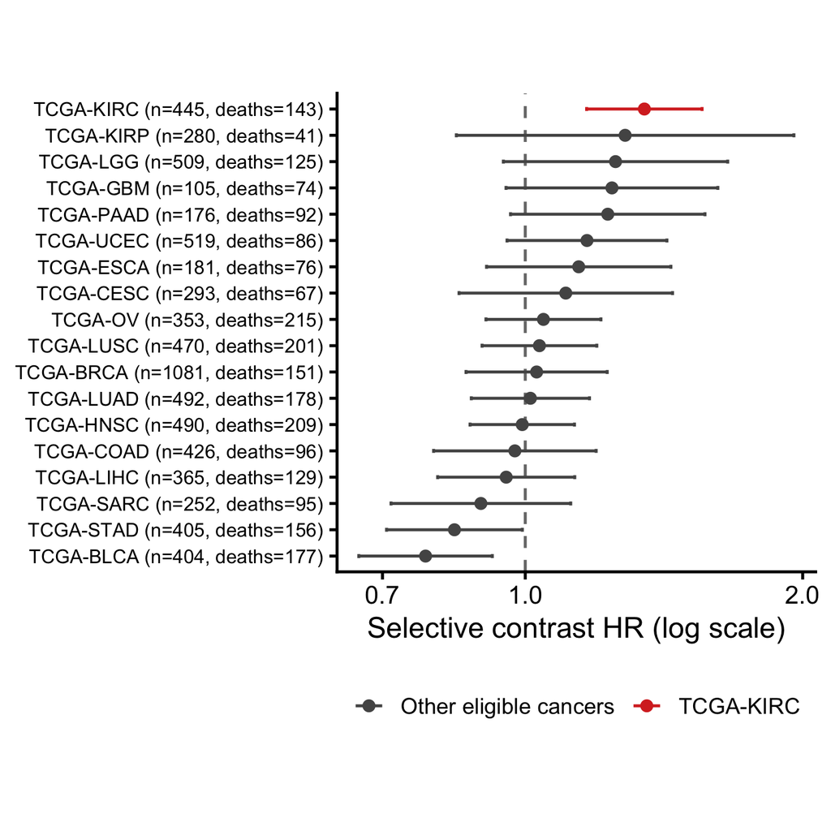

```r
selective_cancer_forest_plot <- make_cancer_forest(
  selective_cancer_results,
  params$selected_selective_project,
  "Selective contrast HR (log scale)"
)

selective_cancer_forest_plot
```

```r
ggsave(
  file.path(
    figure_output_dir,
    "tcga_dmai_selective_survival_forest_panel.pdf"
  ),
  plot = selective_cancer_forest_plot,
  device = pdf,
  width = 6,
  height = 6,
  units = "in"
)
```

## KIRC selective DMAi survival analysis

```r
selected_direct_result <- direct_cancer_results[
  project_id == params$selected_direct_project
]
selected_selective_result <- selective_cancer_results[
  project_id == params$selected_selective_project
]
if (!nrow(selected_direct_result) || !nrow(selected_selective_result)) {
  stop("A selected cancer did not meet the screen eligibility criteria.")
}
if (selected_direct_result$evidence_rank != 1L) {
  warning(params$selected_direct_project, " is not first in the direct screen.")
}
if (selected_selective_result$evidence_rank != 1L) {
  warning(
    params$selected_selective_project,
    " is not first in the selective screen."
  )
}

selected_data <- copy(
  analysis_data[project_id == params$selected_selective_project]
)

prediction_levels <- names(prediction_colours)
selective_contrast_quantiles_z <- quantile(
  selected_data$selective_dmai_usage_z,
  probs = c(0.25, 0.75),
  names = FALSE
)
selective_contrast_quantiles_raw <- quantile(
  selected_data$selective_dmai_usage,
  probs = c(0.25, 0.75),
  names = FALSE
)

selected_qc <- data.table(
  project_id = params$selected_selective_project,
  patients = nrow(selected_data),
  deaths = sum(selected_data$os_event),
  dmai_non_dmai_spearman = cor(
    selected_data$dmai_median_usage,
    selected_data$non_dmai_median_usage,
    method = "spearman"
  ),
  mean_selective_contrast = mean(selected_data$selective_dmai_usage),
  sd_selective_contrast = sd(selected_data$selective_dmai_usage),
  contrast_25th_percentile = selective_contrast_quantiles_raw[1L],
  contrast_75th_percentile = selective_contrast_quantiles_raw[2L]
)
kable(
  selected_qc,
  digits = 4,
  caption = "KIRC selective DMAi contrast summary"
)
```

KIRC selective DMAi contrast summary

| project_id | patients | deaths | dmai_non_dmai_spearman | mean_selective_contrast | sd_selective_contrast | contrast_25th_percentile | contrast_75th_percentile |
| --- | --- | --- | --- | --- | --- | --- | --- |
| TCGA-KIRC | 445 | 143 | 0.9465 | -0.0078 | 0.015 | -0.0163 | 8e-04 |

```r
kirc_selective_fit <- coxph(
  Surv(os_months, os_event) ~
    selective_dmai_usage_z +
    overall_apa_usage_z +
    age_per_10_years +
    sex,
  data = selected_data,
  ties = "efron",
  x = TRUE
)

kirc_model_results <- tidy_score_term(
  kirc_selective_fit,
  "selective_dmai_usage_z",
  "Selective DMAi contrast, overall APA/age/sex adjusted"
)
kable(
  kirc_model_results,
  digits = 4,
  caption = "KIRC selective DMAi overall-survival models"
)
```

KIRC selective DMAi overall-survival models

| model | hazard_ratio | conf_low | conf_high | p_value |
| --- | --- | --- | --- | --- |
| Selective DMAi contrast, overall APA/age/sex adjusted | 1.3466 | 1.1658 | 1.5555 | 1e-04 |

```r
plot_limit <- min(
  as.numeric(params$selected_survival_max_months),
  max(selected_data$os_months)
)
prediction_times <- seq(0, plot_limit, by = 1)

predict_marginal_survival <- function(
  fit,
  patient_data,
  contrast_value_z,
  contrast_label,
  times
) {
  counterfactual_data <- copy(patient_data)
  counterfactual_data[, selective_dmai_usage_z := contrast_value_z]
  prediction <- survfit(
    fit,
    newdata = counterfactual_data,
    se.fit = FALSE
  )
  prediction_at_times <- summary(
    prediction,
    times = times,
    extend = TRUE
  )
  predicted_survival <- prediction_at_times$surv
  if (is.null(dim(predicted_survival))) {
    predicted_survival <- matrix(
      predicted_survival,
      nrow = length(times)
    )
  } else {
    predicted_survival <- as.matrix(predicted_survival)
  }
  if (
    nrow(predicted_survival) != length(times) &&
      ncol(predicted_survival) == length(times)
  ) {
    predicted_survival <- t(predicted_survival)
  }
  if (nrow(predicted_survival) != length(times)) {
    stop("Predicted survival did not match the requested time grid.")
  }
  data.table(
    time = times,
    survival = rowMeans(predicted_survival),
    contrast_level = contrast_label
  )
}

kirc_adjusted_survival <- rbindlist(list(
  predict_marginal_survival(
    kirc_selective_fit,
    selected_data,
    selective_contrast_quantiles_z[1L],
    prediction_levels[1L],
    prediction_times
  ),
  predict_marginal_survival(
    kirc_selective_fit,
    selected_data,
    selective_contrast_quantiles_z[2L],
    prediction_levels[2L],
    prediction_times
  )
))
kirc_adjusted_survival[, contrast_level := factor(
  contrast_level,
  levels = prediction_levels
)]

bootstrap_replicates <- as.integer(
  params$survival_bootstrap_replicates
)
bootstrap_seed <- as.integer(params$survival_bootstrap_seed)
if (!is.finite(bootstrap_replicates) || bootstrap_replicates < 100L) {
  stop("`survival_bootstrap_replicates` must be at least 100.")
}
if (!is.finite(bootstrap_seed)) {
  stop("`survival_bootstrap_seed` must be a finite integer.")
}

bootstrap_prediction <- function(iteration) {
  bootstrap_indices <- sample.int(
    nrow(selected_data),
    replace = TRUE
  )
  bootstrap_data <- copy(selected_data[bootstrap_indices])
  bootstrap_fit <- tryCatch(
    coxph(
      Surv(os_months, os_event) ~
        selective_dmai_usage_z +
        overall_apa_usage_z +
        age_per_10_years +
        sex,
      data = bootstrap_data,
      ties = "efron",
      x = TRUE
    ),
    error = function(e) NULL
  )
  if (is.null(bootstrap_fit)) {
    return(rep(
      NA_real_,
      length(prediction_levels) * length(prediction_times)
    ))
  }

  tryCatch(
    unlist(lapply(seq_along(prediction_levels), function(level_index) {
      predict_marginal_survival(
        bootstrap_fit,
        bootstrap_data,
        selective_contrast_quantiles_z[level_index],
        prediction_levels[level_index],
        prediction_times
      )$survival
    }), use.names = FALSE),
    error = function(e) rep(
      NA_real_,
      length(prediction_levels) * length(prediction_times)
    )
  )
}

set.seed(bootstrap_seed)
bootstrap_survival_matrix <- vapply(
  seq_len(bootstrap_replicates),
  bootstrap_prediction,
  numeric(length(prediction_levels) * length(prediction_times))
)
successful_bootstraps <- colSums(
  is.finite(bootstrap_survival_matrix)
) == nrow(bootstrap_survival_matrix)
number_successful_bootstraps <- sum(successful_bootstraps)
if (number_successful_bootstraps < 0.9 * bootstrap_replicates) {
  stop(
    "Fewer than 90% of adjusted-survival bootstrap fits succeeded (",
    number_successful_bootstraps,
    "/",
    bootstrap_replicates,
    ")."
  )
}

bootstrap_intervals <- t(apply(
  bootstrap_survival_matrix[, successful_bootstraps, drop = FALSE],
  1L,
  quantile,
  probs = c(0.025, 0.975),
  names = FALSE,
  type = 6
))
kirc_adjusted_survival[, `:=`(
  conf_low = bootstrap_intervals[, 1L],
  conf_high = bootstrap_intervals[, 2L]
)]

bootstrap_diagnostics <- data.table(
  requested_resamples = bootstrap_replicates,
  successful_resamples = number_successful_bootstraps,
  random_seed = bootstrap_seed,
  interval = "Pointwise 95% percentile bootstrap CI",
  prediction_time_step_months = 1
)

survival_summary_months <- as.numeric(params$survival_summary_months)
if (
  !is.finite(survival_summary_months) ||
    survival_summary_months < 0 ||
    !survival_summary_months %in% prediction_times
) {
  stop(
    "`survival_summary_months` must be a non-negative value on the ",
    "adjusted-survival prediction grid."
  )
}
summary_row_indices <- vapply(
  prediction_levels,
  function(level) {
    matching_rows <- which(
      kirc_adjusted_survival$contrast_level == level &
        kirc_adjusted_survival$time == survival_summary_months
    )
    if (length(matching_rows) != 1L) {
      stop("Could not identify one survival-summary row per scenario.")
    }
    matching_rows
  },
  integer(1)
)
lower_usage_survival <- kirc_adjusted_survival$survival[
  summary_row_indices[1L]
]
higher_usage_survival <- kirc_adjusted_survival$survival[
  summary_row_indices[2L]
]
bootstrap_survival_difference <-
  bootstrap_survival_matrix[
    summary_row_indices[1L],
    successful_bootstraps
  ] -
  bootstrap_survival_matrix[
    summary_row_indices[2L],
    successful_bootstraps
  ]
survival_difference_interval <- quantile(
  bootstrap_survival_difference,
  probs = c(0.025, 0.975),
  names = FALSE,
  type = 6
)

adjusted_survival_difference <- data.table(
  time_months = survival_summary_months,
  lower_relative_usage_survival = lower_usage_survival,
  higher_relative_usage_survival = higher_usage_survival,
  survival_difference_lower_minus_higher =
    lower_usage_survival - higher_usage_survival,
  difference_conf_low = survival_difference_interval[1L],
  difference_conf_high = survival_difference_interval[2L],
  interpretation = paste0(
    "Absolute adjusted survival difference; equivalently, excess ",
    "mortality risk for higher versus lower relative DMAi-site usage"
  )
)

prediction_summary <- data.table(
  contrast_level = prediction_levels,
  selective_contrast_raw = selective_contrast_quantiles_raw,
  selective_contrast_z = selective_contrast_quantiles_z
)
kable(
  prediction_summary,
  digits = 4,
  caption = "KIRC selective-contrast values used for adjusted survival"
)
```

KIRC selective-contrast values used for adjusted survival

| contrast_level | selective_contrast_raw | selective_contrast_z |
| --- | --- | --- |
| Lower relative DMAi-site usage (25th percentile) | -0.0163 | -0.5694 |
| Higher relative DMAi-site usage (75th percentile) | 0.0008 | 0.5743 |

```r
kable(
  bootstrap_diagnostics,
  caption = "Adjusted-survival bootstrap diagnostics"
)
```

Adjusted-survival bootstrap diagnostics

| requested_resamples | successful_resamples | random_seed | interval | prediction_time_step_months |
| --- | --- | --- | --- | --- |
| 500 | 500 | 20260805 | Pointwise 95% percentile bootstrap CI | 1 |

```r
kable(
  adjusted_survival_difference[, .(
    time_months,
    lower_relative_usage_survival,
    higher_relative_usage_survival,
    survival_difference_lower_minus_higher,
    difference_conf_low,
    difference_conf_high
  )],
  digits = 4,
  caption = paste0(
    "Adjusted survival difference at ",
    survival_summary_months,
    " months (paired-bootstrap 95% CI)"
  )
)
```

Adjusted survival difference at 60 months (paired-bootstrap 95% CI)

| time_months | lower_relative_usage_survival | higher_relative_usage_survival | survival_difference_lower_minus_higher | difference_conf_low | difference_conf_high |
| --- | --- | --- | --- | --- | --- |
| 60 | 0.6956 | 0.6052 | 0.0904 | 0.0406 | 0.1722 |

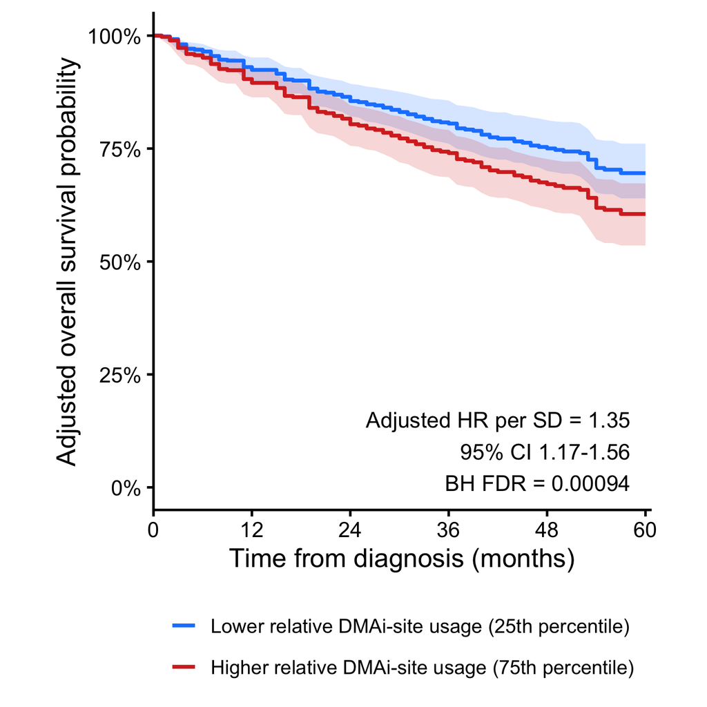

```r
kirc_adjusted_survival_plot <- ggplot(
  kirc_adjusted_survival,
  aes(
    time,
    survival,
    colour = contrast_level,
    group = contrast_level
  )
) +
  geom_ribbon(
    aes(
      ymin = conf_low,
      ymax = conf_high,
      fill = contrast_level
    ),
    alpha = 0.18,
    colour = NA,
    show.legend = FALSE
  ) +
  geom_step(linewidth = 1.1) +
  scale_colour_manual(values = prediction_colours, drop = FALSE) +
  scale_fill_manual(values = prediction_colours, drop = FALSE) +
  scale_x_continuous(
    limits = c(0, plot_limit),
    breaks = seq(0, plot_limit, by = 12),
    expand = expansion(mult = c(0, 0.01))
  ) +
  scale_y_continuous(
    limits = c(0, 1),
    labels = label_percent(accuracy = 1)
  ) +
  annotate(
    "text",
    x = 0.97 * plot_limit,
    y = 0.08,
    hjust = 1,
    label = paste0(
      "Adjusted HR per SD = ",
      sprintf("%.2f", selected_selective_result$hazard_ratio),
      "\n95% CI ",
      sprintf("%.2f", selected_selective_result$conf_low),
      "-",
      sprintf("%.2f", selected_selective_result$conf_high),
      "\nBH FDR = ",
      format.pval(selected_selective_result$p_adjusted, digits = 2)
    ),
    size = 4.7
  ) +
  labs(
    x = "Time from diagnosis (months)",
    y = "Adjusted overall survival probability",
    colour = NULL
  ) +
  theme_classic(base_size = 16) +
  guides(
    colour = guide_legend(nrow = 2, byrow = TRUE)
  ) +
  theme(
    aspect.ratio = 1,
    axis.text = element_text(size = 13),
    axis.title = element_text(size = 16),
    legend.position = "bottom",
    legend.text = element_text(size = 12)
  )

kirc_adjusted_survival_plot
```

```r
ggsave(
  file.path(
    figure_output_dir,
    "tcga_kirc_dmai_selective_adjusted_survival_panel.pdf"
  ),
  plot = kirc_adjusted_survival_plot,
  device = pdf,
  width = 6,
  height = 6,
  units = "in"
)
```

## Manuscript results paragraph

```r
pan_dmai <- pan_cancer_results[model == "DMAi"]
pan_non_dmai <- pan_cancer_results[model == "non-DMAi"]
pan_selective <- selective_pan_cancer_results[
  model == "Selective DMAi usage"
]
pan_overall_apa <- selective_pan_cancer_results[
  model == "Overall APA usage"
]
kirc_selective <- selected_selective_result
blca_selective <- selective_cancer_results[
  project_id == "TCGA-BLCA"
]
paad_selective <- selective_cancer_results[
  project_id == params$selected_direct_project
]
kirc_survival_difference <- adjusted_survival_difference[1L]

cat(sprintf(
  paste0(
    "Among %s TCGA patients with primary tumours (%s deaths across %s ",
    "cancer projects), the DMAi score itself was first analysed as a ",
    "direct, non-contrast metric. Higher DMAi-site usage was associated ",
    "with poorer overall survival after adjustment for age and sex, ",
    "stratification by ",
    "cancer project, and inclusion of non-DMAi usage (HR %.2f per ",
    "within-cancer SD, 95%% CI %.2f--%.2f; p = %s). Non-DMAi usage was ",
    "not independently associated with survival (HR %.2f, 95%% CI ",
    "%.2f--%.2f; p = %s). In an exploratory cancer-specific screen ",
    "of %s cancer types meeting the prespecified patient and event ",
    "thresholds, pancreatic adenocarcinoma (PAAD) showed the largest ",
    "adverse DMAi association (HR %.2f, 95%% CI %.2f--%.2f; nominal ",
    "p = %s; BH FDR = %s). Selective DMAi usage was then defined as the ",
    "within-patient DMAi-minus-non-DMAi contrast and analysed while ",
    "controlling for overall APA usage. This contrast was not associated ",
    "with survival pan-cancer (HR %.2f, 95%% CI %.2f--%.2f; p = %s), ",
    "whereas overall APA usage was (HR %.2f, 95%% CI %.2f--%.2f; ",
    "p = %s). In the cancer-specific selective screen, kidney renal clear ",
    "cell carcinoma (KIRC) showed the strongest adverse association ",
    "(HR %.2f, 95%% CI %.2f--%.2f; nominal p = %s; BH FDR = %s), while ",
    "bladder urothelial carcinoma showed an inverse association (HR %.2f, ",
    "95%% CI %.2f--%.2f; nominal p = %s; BH FDR = %s). The selective ",
    "contrast was not significant in PAAD (HR %.2f, 95%% CI %.2f--%.2f; ",
    "p = %s; BH FDR = %s), indicating that direct and selective DMAi ",
    "metrics identify different cancer-specific associations. Adjusted ",
    "survival predictions with pointwise bootstrap 95%% confidence bands ",
    "at the 25th and 75th percentiles were used to visualize the continuous ",
    "KIRC association without dichotomizing patients. At %s months, adjusted ",
    "survival was %.1f%% at the 75th percentile and %.1f%% at the 25th ",
    "percentile, an absolute difference of %.1f percentage points ",
    "(paired-bootstrap 95%% CI %.1f--%.1f). These cancer-specific findings ",
    "are exploratory."
  ),
  comma(nrow(analysis_data)),
  comma(sum(analysis_data$os_event)),
  uniqueN(analysis_data$project_id),
  pan_dmai$hazard_ratio,
  pan_dmai$conf_low,
  pan_dmai$conf_high,
  format.pval(pan_dmai$p_value, digits = 2),
  pan_non_dmai$hazard_ratio,
  pan_non_dmai$conf_low,
  pan_non_dmai$conf_high,
  format.pval(pan_non_dmai$p_value, digits = 2),
  nrow(direct_cancer_results),
  selected_direct_result$hazard_ratio,
  selected_direct_result$conf_low,
  selected_direct_result$conf_high,
  format.pval(selected_direct_result$p_value, digits = 2),
  format.pval(selected_direct_result$p_adjusted, digits = 2),
  pan_selective$hazard_ratio,
  pan_selective$conf_low,
  pan_selective$conf_high,
  format.pval(pan_selective$p_value, digits = 2),
  pan_overall_apa$hazard_ratio,
  pan_overall_apa$conf_low,
  pan_overall_apa$conf_high,
  format.pval(pan_overall_apa$p_value, digits = 2),
  kirc_selective$hazard_ratio,
  kirc_selective$conf_low,
  kirc_selective$conf_high,
  format.pval(kirc_selective$p_value, digits = 2),
  format.pval(kirc_selective$p_adjusted, digits = 2),
  blca_selective$hazard_ratio,
  blca_selective$conf_low,
  blca_selective$conf_high,
  format.pval(blca_selective$p_value, digits = 2),
  format.pval(blca_selective$p_adjusted, digits = 2),
  paad_selective$hazard_ratio,
  paad_selective$conf_low,
  paad_selective$conf_high,
  format.pval(paad_selective$p_value, digits = 2),
  format.pval(paad_selective$p_adjusted, digits = 2),
  format(kirc_survival_difference$time_months, trim = TRUE),
  100 * kirc_survival_difference$higher_relative_usage_survival,
  100 * kirc_survival_difference$lower_relative_usage_survival,
  100 * kirc_survival_difference$survival_difference_lower_minus_higher,
  100 * kirc_survival_difference$difference_conf_low,
  100 * kirc_survival_difference$difference_conf_high
))
```

Among 9,227 TCGA patients with primary tumours (2,555 deaths across 31 cancer projects), the DMAi score itself was first analysed as a direct, non-contrast metric. Higher DMAi-site usage was associated with poorer overall survival after adjustment for age and sex, stratification by cancer project, and inclusion of non-DMAi usage (HR 1.11 per within-cancer SD, 95% CI 1.01–1.21; p = 0.028). Non-DMAi usage was not independently associated with survival (HR 0.98, 95% CI 0.90–1.08; p = 0.71). In an exploratory cancer-specific screen of 18 cancer types meeting the prespecified patient and event thresholds, pancreatic adenocarcinoma (PAAD) showed the largest adverse DMAi association (HR 1.57, 95% CI 1.23–2.00; nominal p = 0.00025; BH FDR = 0.0045). Selective DMAi usage was then defined as the within-patient DMAi-minus-non-DMAi contrast and analysed while controlling for overall APA usage. This contrast was not associated with survival pan-cancer (HR 1.03, 95% CI 0.99–1.08; p = 0.1), whereas overall APA usage was (HR 1.08, 95% CI 1.03–1.12; p = 0.00036). In the cancer-specific selective screen, kidney renal clear cell carcinoma (KIRC) showed the strongest adverse association (HR 1.35, 95% CI 1.17–1.56; nominal p = 5.2e-05; BH FDR = 0.00094), while bladder urothelial carcinoma showed an inverse association (HR 0.78, 95% CI 0.66–0.92; nominal p = 0.0034; BH FDR = 0.031). The selective contrast was not significant in PAAD (HR 1.23, 95% CI 0.96–1.57; p = 0.096; BH FDR = 0.33), indicating that direct and selective DMAi metrics identify different cancer-specific associations. Adjusted survival predictions with pointwise bootstrap 95% confidence bands at the 25th and 75th percentiles were used to visualize the continuous KIRC association without dichotomizing patients. At 60 months, adjusted survival was 60.5% at the 75th percentile and 69.6% at the 25th percentile, an absolute difference of 9.0 percentage points (paired-bootstrap 95% CI 4.1–17.2). These cancer-specific findings are exploratory.

## Reproducibility outputs

```r
output_dir <- results_output_dir

fwrite(
  analysis_data,
  file.path(output_dir, "tcga_dmai_os_manuscript_cohort.tsv"),
  sep = "\t"
)
fwrite(
  pan_cancer_results,
  file.path(output_dir, "tcga_dmai_os_manuscript_pan_cancer_cox.tsv"),
  sep = "\t"
)
fwrite(
  pan_cancer_ph_results,
  file.path(output_dir, "tcga_dmai_os_manuscript_ph_tests.tsv"),
  sep = "\t"
)
fwrite(
  selective_pan_cancer_results,
  file.path(output_dir, "tcga_dmai_os_selective_pan_cancer_cox.tsv"),
  sep = "\t"
)
fwrite(
  selective_pan_cancer_ph_results,
  file.path(output_dir, "tcga_dmai_os_selective_ph_tests.tsv"),
  sep = "\t"
)
fwrite(
  direct_cancer_results,
  file.path(output_dir, "tcga_dmai_os_direct_cancer_screen.tsv"),
  sep = "\t"
)
fwrite(
  direct_cancer_results,
  file.path(output_dir, "tcga_dmai_os_manuscript_cancer_screen.tsv"),
  sep = "\t"
)
fwrite(
  selective_cancer_results,
  file.path(output_dir, "tcga_dmai_os_selective_cancer_screen.tsv"),
  sep = "\t"
)
fwrite(
  cancer_screen_results,
  file.path(output_dir, "tcga_dmai_os_combined_cancer_screen.tsv"),
  sep = "\t"
)
fwrite(
  cancer_variability,
  file.path(output_dir, "tcga_dmai_os_manuscript_variability.tsv"),
  sep = "\t"
)
fwrite(
  selected_data,
  file.path(output_dir, "tcga_dmai_os_kirc_selective_data.tsv"),
  sep = "\t"
)
fwrite(
  kirc_model_results,
  file.path(output_dir, "tcga_dmai_os_kirc_selective_models.tsv"),
  sep = "\t"
)
fwrite(
  prediction_summary,
  file.path(output_dir, "tcga_dmai_os_kirc_prediction_values.tsv"),
  sep = "\t"
)
fwrite(
  kirc_adjusted_survival,
  file.path(output_dir, "tcga_dmai_os_kirc_adjusted_survival.tsv"),
  sep = "\t"
)
fwrite(
  bootstrap_diagnostics,
  file.path(output_dir, "tcga_dmai_os_kirc_bootstrap_diagnostics.tsv"),
  sep = "\t"
)
fwrite(
  adjusted_survival_difference,
  file.path(
    output_dir,
    "tcga_dmai_os_kirc_adjusted_survival_difference.tsv"
  ),
  sep = "\t"
)
```